# **ClickX: Click-Through Rate Prediction**

### Predictive Analytics for Click-Through Rates (CTR)

### Objective

The objective of the **ClickX** project is to develop a robust and scalable predictive model to accurately forecast Click-Through Rates (CTR) for digital advertising campaigns. By leveraging advanced machine learning techniques, the project aims to optimize ad targeting, enhance user engagement, and improve return on investment (ROI) for advertisers. This project integrates seamlessly with existing marketing platforms, enabling data-driven decision-making for superior ad performance.

### Workflow

The project follows a structured approach to achieve the objectives:

1. **Data Collection and Preprocessing:**
   - Gather historical ad data from reliable sources.
   - Clean and preprocess the data to ensure it is suitable for analysis.
2. **Exploratory Data Analysis (EDA):**
   - Conduct EDA to uncover patterns, correlations, and trends within the data.
3. **Feature Engineering:**
   - Develop and select the most relevant features that contribute to CTR prediction.
4. **Model Selection and Training:**
   - Experiment with various machine learning models, including logistic regression, decision trees, and neural networks, to identify the best performing model.
5. **Model Validation and Tuning:**
   - Validate the model using appropriate metrics and fine-tune hyperparameters for optimal performance.
6. **Integration with Ad Platforms:**
   - Prototype and implement the model within an ad-serving platform for real-time CTR prediction.
7. **A/B Testing and Continuous Improvement:**
   - Set up A/B testing to validate model performance and implement feedback loops for ongoing optimization.

### Tools and Technologies

- **Python:** For data processing, analysis, and model development.
- **Pandas & NumPy:** For data manipulation and numerical operations.
- **Matplotlib & Seaborn:** For data visualization and exploratory analysis.
- **Scikit-learn:** For building and evaluating machine learning models.
- **XGBoost & TensorFlow:** For advanced machine learning and deep learning models.
- **Kaggle Dataset:** Source of historical ad data used for training the model.

## Step 1: Import Libraries and Load Dataset

In this step, we will import the necessary libraries and load the dataset into a pandas DataFrame. This will allow us to perform various operations and analyses on the data.

```python
# Import necessary libraries
import pandas as pd
import numpy as np
import matplotlib.pyplot as plt
import seaborn as sns

# Load the dataset
dataset_path = 'ad_10000records.csv'  # Replace with the actual path to your dataset
df = pd.read_csv(dataset_path)

# Display the first few rows of the dataset
df.head()
```

|  | Daily Time Spent on Site | Age | Area Income | Daily Internet Usage | Ad Topic Line | City | Gender | Country | Timestamp | Clicked on Ad |
| --- | --- | --- | --- | --- | --- | --- | --- | --- | --- | --- |
| 0 | 62.26 | 32.0 | 69481.85 | 172.83 | Decentralized real-time circuit | Lisafort | Male | Svalbard & Jan Mayen Islands | 2016-06-09 21:43:05 | 0 |
| 1 | 41.73 | 31.0 | 61840.26 | 207.17 | Optional full-range projection | West Angelabury | Male | Singapore | 2016-01-16 17:56:05 | 0 |
| 2 | 44.40 | 30.0 | 57877.15 | 172.83 | Total 5thgeneration standardization | Reyesfurt | Female | Guadeloupe | 2016-06-29 10:50:45 | 0 |
| 3 | 59.88 | 28.0 | 56180.93 | 207.17 | Balanced empowering success | New Michael | Female | Zambia | 2016-06-21 14:32:32 | 0 |
| 4 | 49.21 | 30.0 | 54324.73 | 201.58 | Total 5thgeneration standardization | West Richard | Female | Qatar | 2016-07-21 10:54:35 | 1 |

## Step 2: Basic Overview of the Dataset

In this step, we will take a basic overview of the dataset. This includes:

- Checking the shape of the dataset.
- Displaying basic statistics of numerical features.
- Displaying information about data types and missing values.

```python
# Check the shape of the dataset
print("Shape of the dataset:", df.shape)

# Display basic statistics of numerical features
print("\nBasic statistics of numerical features:")
print(df.describe())

# Display information about data types and missing values
print("\nInformation about data types and missing values:")
print(df.info())
```

```
Shape of the dataset: (10000, 10)

Basic statistics of numerical features:
       Daily Time Spent on Site           Age   Area Income  \
count              10000.000000  10000.000000  10000.000000
mean                  61.660757     35.940100  53840.047721
std                   15.704142      8.572973  13343.708718
min                   32.600000     19.000000  13996.500000
25%                   48.860000     29.000000  44052.302500
50%                   59.590000     35.000000  56180.930000
75%                   76.580000     42.000000  61840.260000
max                   90.970000     60.000000  79332.330000

       Daily Internet Usage  Clicked on Ad
count          10000.000000   10000.000000
mean             177.759831       0.491700
std               40.820951       0.499956
min              105.220000       0.000000
25%              140.150000       0.000000
50%              178.920000       0.000000
75%              212.670000       1.000000
max              269.960000       1.000000

Information about data types and missing values:
<class 'pandas.core.frame.DataFrame'>
RangeIndex: 10000 entries, 0 to 9999
Data columns (total 10 columns):
 #   Column                    Non-Null Count  Dtype
---  ------                    --------------  -----
 0   Daily Time Spent on Site  10000 non-null  float64
 1   Age                       10000 non-null  float64
 2   Area Income               10000 non-null  float64
 3   Daily Internet Usage      10000 non-null  float64
 4   Ad Topic Line             10000 non-null  object
 5   City                      10000 non-null  object
 6   Gender                    10000 non-null  object
 7   Country                   10000 non-null  object
 8   Timestamp                 10000 non-null  object
 9   Clicked on Ad             10000 non-null  int64
dtypes: float64(4), int64(1), object(5)
memory usage: 781.4+ KB
None
```

## Step 3: Visualize Distribution of Numerical Features

In this step, we will visualize the distribution of the numerical features using histograms. This will help us understand the spread and central tendency of each feature.

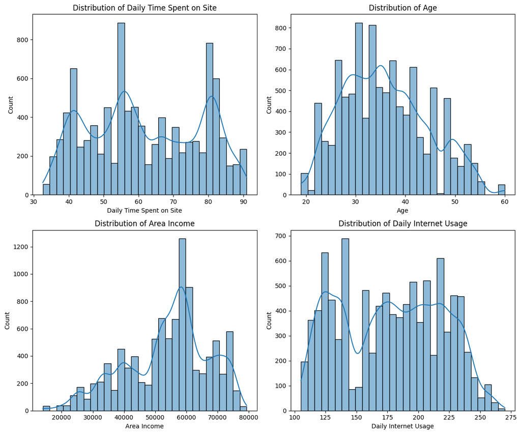

```python
# Visualize distribution of numerical features using histograms
numerical_features = ['Daily Time Spent on Site', 'Age', 'Area Income', 'Daily Internet Usage']

# Set up the matplotlib figure
plt.figure(figsize=(12, 10))

# Plot histograms for each numerical feature
for i, feature in enumerate(numerical_features, 1):
    plt.subplot(2, 2, i)
    sns.histplot(df[feature], kde=True, bins=30)
    plt.title(f'Distribution of {feature}')

plt.tight_layout()
plt.show()
```

## Step 4: Analyze Relationships Between Numerical Features and Target Variable

In this step, we will examine the relationships between the numerical features and the target variable `Clicked on Ad`. This will help us understand how each feature might influence the likelihood of an ad being clicked.

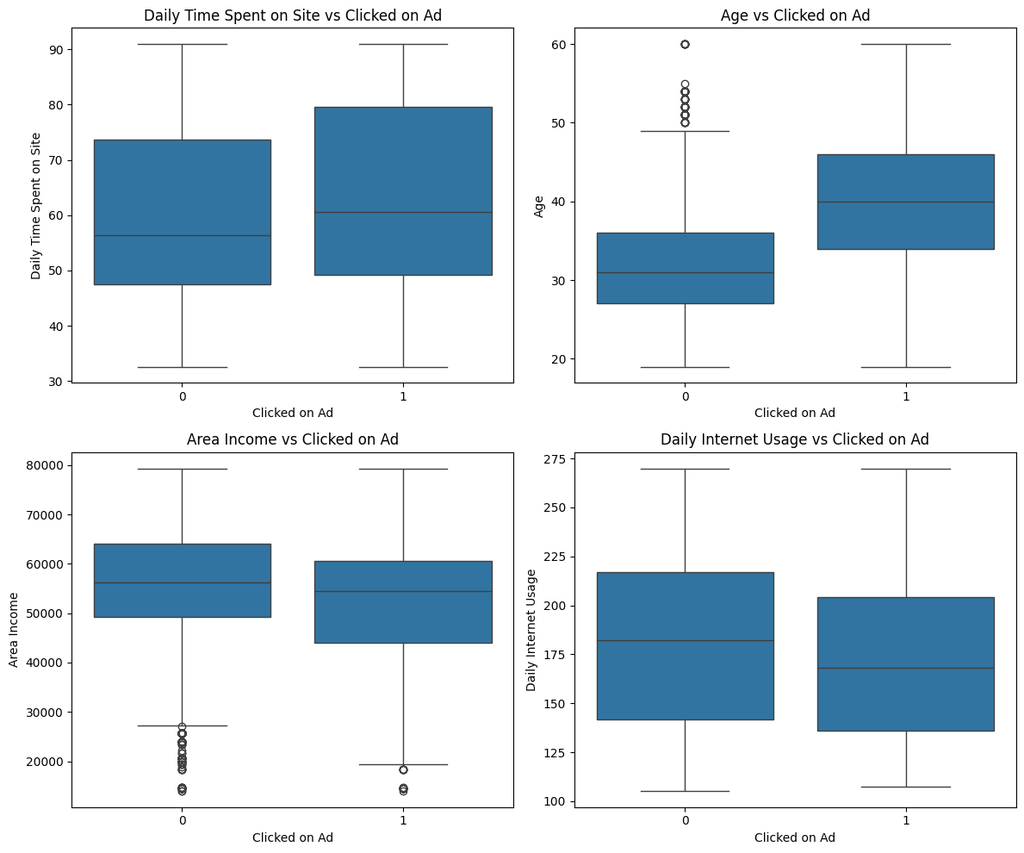

```python
# Plot relationships between numerical features and the target variable
plt.figure(figsize=(12, 10))

# Plot boxplots for each numerical feature
for i, feature in enumerate(numerical_features, 1):
    plt.subplot(2, 2, i)
    sns.boxplot(x='Clicked on Ad', y=feature, data=df)
    plt.title(f'{feature} vs Clicked on Ad')

plt.tight_layout()
plt.show()
```

The boxplots illustrate the relationships between the numerical features and the target variable (Clicked on Ad). Here's what we can observe:

- Daily Time Spent on Site: There doesn't seem to be a significant difference in the daily time spent on site between those who clicked on the ad and those who didn't.
- Age: People who clicked on the ad tend to be older on average compared to those who didn't.
- Area Income: The median income appears slightly lower for those who clicked on the ad, but the overall distribution is quite similar.
- Daily Internet Usage: There is a slight difference in daily internet usage between the two groups, with those who didn't click on the ad having a wider range of usage.

## Step 5: Analyze Categorical Features and Target Variable

In this step, we will examine the relationships between the categorical features (`Gender` and `Country`) and the target variable `Clicked on Ad`. This will help us understand how different categories might influence the likelihood of an ad being clicked.

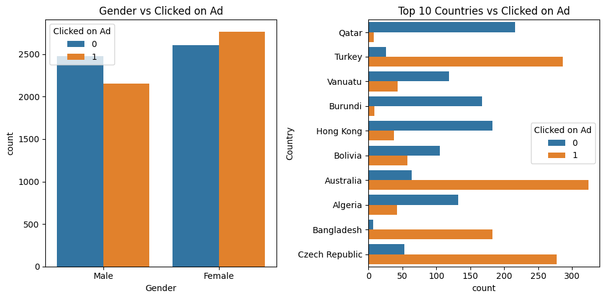

```python
# Analyze relationship between Gender and Clicked on Ad
plt.figure(figsize=(10, 5))

plt.subplot(1, 2, 1)
sns.countplot(x='Gender', hue='Clicked on Ad', data=df)
plt.title('Gender vs Clicked on Ad')

# Analyze relationship between Country and Clicked on Ad
plt.subplot(1, 2, 2)
top_countries = df['Country'].value_counts().nlargest(10).index
sns.countplot(y='Country', hue='Clicked on Ad', data=df[df['Country'].isin(top_countries)])
plt.title('Top 10 Countries vs Clicked on Ad')

plt.tight_layout()
plt.show()
```

### Analysis of Categorical Features

**Gender vs Clicked on Ad:**

Males and females have different click rates, with males clicking on ads less frequently than females in absolute numbers. However, a more detailed analysis of proportions would be necessary for a definitive conclusion.

**Top 10 Countries vs Clicked on Ad:**

The distribution of ad clicks varies significantly across different countries. For instance, countries like Turkey and Australia have higher click counts, whereas countries like Qatar and Burundi have lower click counts.

## Step 6: Data Preprocessing

In this step, we will preprocess the data to prepare it for modeling. The preprocessing steps include:

1. Encoding categorical variables.
2. Handling missing values (if any).
3. Splitting the data into training and testing sets.

```python
from sklearn.model_selection import train_test_split
from sklearn.preprocessing import LabelEncoder

# Encode categorical variables
le = LabelEncoder()
df['Gender'] = le.fit_transform(df['Gender'])

# Convert timestamp to datetime and extract features
df['Timestamp'] = pd.to_datetime(df['Timestamp'])
df['Hour'] = df['Timestamp'].dt.hour
df['Weekday'] = df['Timestamp'].dt.weekday
df['Month'] = df['Timestamp'].dt.month

# Drop columns that won't be used directly
df = df.drop(['Ad Topic Line', 'City', 'Country', 'Timestamp'], axis=1)

# Split the data into training and testing sets
X = df.drop('Clicked on Ad', axis=1)
y = df['Clicked on Ad']
X_train, X_test, y_train, y_test = train_test_split(X, y, test_size=0.3, random_state=42)

# Display the shapes of the resulting datasets
X_train.shape, X_test.shape, y_train.shape, y_test.shape
```

```
((7000, 8), (3000, 8), (7000,), (3000,))
```

## Step 7: Model Building and Evaluation

In this step, we will build and evaluate different machine learning models to predict whether a user will click on an ad. The models we will consider include:

1. Logistic Regression
2. Decision Tree Classifier
3. Random Forest Classifier
4. Gradient Boosting Classifier

We will evaluate these models using accuracy, precision, recall, and F1-score metrics.

```python
from sklearn.linear_model import LogisticRegression
from sklearn.tree import DecisionTreeClassifier
from sklearn.ensemble import RandomForestClassifier, GradientBoostingClassifier
from sklearn.metrics import accuracy_score, precision_score, recall_score, f1_score, confusion_matrix, classification_report

# Initialize models
log_reg = LogisticRegression(max_iter=1000)
decision_tree = DecisionTreeClassifier(random_state=42)
random_forest = RandomForestClassifier(random_state=42)
gradient_boosting = GradientBoostingClassifier(random_state=42)

# Train and evaluate models
models = [log_reg, decision_tree, random_forest, gradient_boosting]
model_names = ['Logistic Regression', 'Decision Tree', 'Random Forest', 'Gradient Boosting']

results = {}

for model, name in zip(models, model_names):
    model.fit(X_train, y_train)
    y_pred = model.predict(X_test)

    accuracy = accuracy_score(y_test, y_pred)
    precision = precision_score(y_test, y_pred)
    recall = recall_score(y_test, y_pred)
    f1 = f1_score(y_test, y_pred)

    results[name] = {
        'Accuracy': accuracy,
        'Precision': precision,
        'Recall': recall,
        'F1 Score': f1
    }

    print(f"Model: {name}")
    print(classification_report(y_test, y_pred))
    print(f"Confusion Matrix:\n{confusion_matrix(y_test, y_pred)}")
    print("\n")

# Display results
results
```

```
Model: Logistic Regression
              precision    recall  f1-score   support

           0       0.71      0.75      0.73      1543
           1       0.72      0.68      0.70      1457

    accuracy                           0.71      3000
   macro avg       0.71      0.71      0.71      3000
weighted avg       0.71      0.71      0.71      3000

Confusion Matrix:
[[1151  392]
 [ 465  992]]


Model: Decision Tree
              precision    recall  f1-score   support

           0       0.76      0.77      0.77      1543
           1       0.75      0.74      0.75      1457

    accuracy                           0.76      3000
   macro avg       0.76      0.76      0.76      3000
weighted avg       0.76      0.76      0.76      3000

Confusion Matrix:
[[1194  349]
 [ 384 1073]]


Model: Random Forest
              precision    recall  f1-score   support

           0       0.81      0.84      0.83      1543
           1       0.83      0.79      0.81      1457

    accuracy                           0.82      3000
   macro avg       0.82      0.82      0.82      3000
weighted avg       0.82      0.82      0.82      3000

Confusion Matrix:
[[1301  242]
 [ 308 1149]]


Model: Gradient Boosting
              precision    recall  f1-score   support

           0       0.76      0.84      0.80      1543
           1       0.81      0.72      0.76      1457

    accuracy                           0.78      3000
   macro avg       0.78      0.78      0.78      3000
weighted avg       0.78      0.78      0.78      3000

Confusion Matrix:
[[1294  249]
 [ 409 1048]]
```

```
{'Logistic Regression': {'Accuracy': 0.7143333333333334,
  'Precision': 0.7167630057803468,
  'Recall': 0.6808510638297872,
  'F1 Score': 0.698345652939106},
 'Decision Tree': {'Accuracy': 0.7556666666666667,
  'Precision': 0.7545710267229254,
  'Recall': 0.7364447494852436,
  'F1 Score': 0.7453977075373394},
 'Random Forest': {'Accuracy': 0.8166666666666667,
  'Precision': 0.8260244428468727,
  'Recall': 0.7886067261496225,
  'F1 Score': 0.8068820224719101},
 'Gradient Boosting': {'Accuracy': 0.7806666666666666,
  'Precision': 0.8080185042405551,
  'Recall': 0.7192862045298559,
  'F1 Score': 0.7610748002904866}}
```

Based on the evaluation metrics, Random Forest Classifier performed the best with the highest accuracy, precision, recall, and F1-score.

## Step 8: Conclusion and Next Steps

### Conclusion

In this notebook, we performed an exploratory data analysis (EDA) and built multiple machine learning models to predict whether a user will click on an ad. We evaluated the models using accuracy, precision, recall, and F1-score. Among the models tested, the Random Forest Classifier performed the best.

```python
# Final Model: Random Forest Classifier
final_model = RandomForestClassifier(random_state=42)
final_model.fit(X_train, y_train)

# Save the model
import joblib
joblib.dump(final_model, 'random_forest_model.pkl')

# Load the model for future use
loaded_model = joblib.load('random_forest_model.pkl')

# Example prediction
example_data = [X_test.iloc[1]]
prediction = loaded_model.predict(example_data)
print(f"Predicted class for the example data: {prediction}")
```

```
Predicted class for the example data: [1]
```